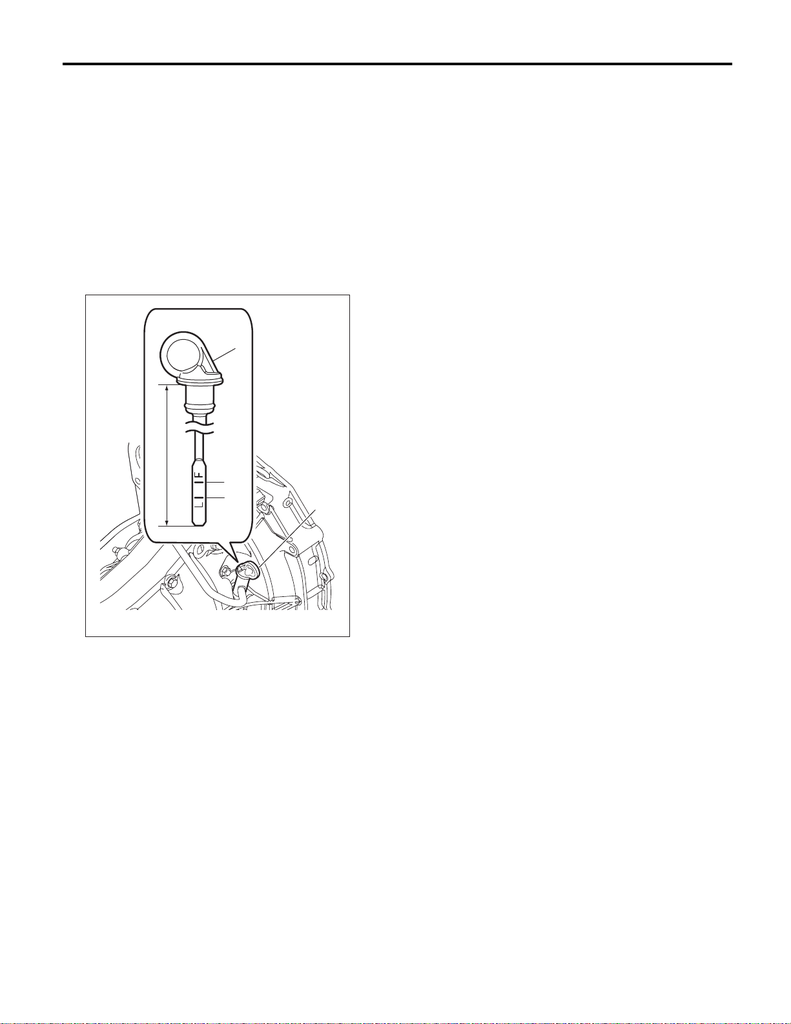

Transmission Gear Oil

MANUAL TRANSMISSION AND DIFFERENTIAL

2. Transmission Gear Oil

A: INSPECTION

1) Park the vehicle on a level surface.

2) Turn the ignition switch to OFF, and wait until the engine cools.

3) Remove the oil level gauge and wipe it clean.

4) Reinsert the oil level gauge all the way. Be sure that the oil level gauge is correctly inserted in the proper

direction.

5) Pull out the oil level gauge again, and check the oil level. If it is below the lower level, check for oil leakage

and add oil through the oil level gauge hole to bring the level up to the upper level.

CAUTION:

The length of the oil level gauge varies depending on models and destinations. Make sure to use the

appropriate oil level gauge.

MT-03061

(A)

(1)

(B)

(C)

(2)

(A) Oil level gauge

(B) Upper level

(C) Lower level

(1) Gray

(2) 195.9 mm (7.71 in)

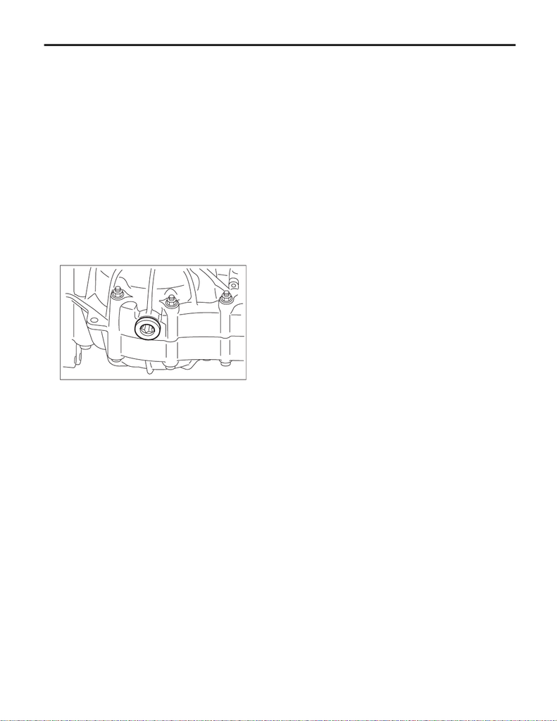

Transmission Gear Oil

MANUAL TRANSMISSION AND DIFFERENTIAL

B: REPLACEMENT

1) Pull out the oil level gauge.

2) Lift up the vehicle.

3) Using the TORX

®

bit T70, remove the drain plug, and drain the transmission gear oil completely.

CAUTION:

• Immediately after the vehicle has been running or after idling for a long time, the transmission gear

oil will be hot. Be careful not to receive burns.

• Be careful not to spill the transmission gear oil on the exhaust pipe, to prevent emission of smoke

or causing a fire. If gear oil is spilt, wipe it off completely.

4) Attach the drain plug using TORX

®

bit T70.

NOTE:

• Install the drain plug after draining transmission gear oil.

• Use a new gasket.

Tightening torque:

44 N·m (4.5 kgf-m, 32.5 ft-lb) (aluminum gasket, silver)

70 N·m (7.1 kgf-m, 51.6 ft-lb) (copper gasket, brown)

70 N·m (7.1 kgf-m, 51.6 ft-lb) (metal gasket, black)

5) Lower the vehicle.

6) Pour gear oil through the oil level gauge hole.

CAUTION:

If an alternative transmission gear oil is used, you may not have expected functionality and perfor-

mance.

Recommended gear oil:

SUBARU GEAR OIL EXTRA MT

Alternative:

GL-5 (75W-90)

Gear oil capacity:

3.3 L (3.5 US qt, 2.9 Imp qt)

7) Check the transmission gear oil amount, and confirm that it is within the specification.

MT-01548